# Part I - Ford GoBike System Data

## Preliminary Wrangling

### Importing packages and loading the dataset

```python
# import all packages and set plots to be embedded inline
import numpy as np
import pandas as pd
import matplotlib.pyplot as plt
import seaborn as sb

%matplotlib inline
```

```python
Bike = pd.read_csv('fordbike.csv')
```

### Exploration of Data

```python
Bike.head()
```

|  | duration_sec | start_time | end_time | start_station_id | start_station_name | start_station_latitude | start_station_longitude | end_station_id | end_station_name | end_station_latitude | end_station_longitude | bike_id | user_type | member_birth_year | member_gender | bike_share_for_all_trip |
| --- | --- | --- | --- | --- | --- | --- | --- | --- | --- | --- | --- | --- | --- | --- | --- | --- |
| 0 | 52185 | 2019-02-28 17:32:10.1450 | 2019-03-01 08:01:55.9750 | 21.0 | Montgomery St BART Station (Market St at 2nd St) | 37.789625 | -122.400811 | 13.0 | Commercial St at Montgomery St | 37.794231 | -122.402923 | 4902 | Customer | 1984.0 | Male | No |
| 1 | 42521 | 2019-02-28 18:53:21.7890 | 2019-03-01 06:42:03.0560 | 23.0 | The Embarcadero at Steuart St | 37.791464 | -122.391034 | 81.0 | Berry St at 4th St | 37.775880 | -122.393170 | 2535 | Customer | NaN | NaN | No |
| 2 | 61854 | 2019-02-28 12:13:13.2180 | 2019-03-01 05:24:08.1460 | 86.0 | Market St at Dolores St | 37.769305 | -122.426826 | 3.0 | Powell St BART Station (Market St at 4th St) | 37.786375 | -122.404904 | 5905 | Customer | 1972.0 | Male | No |
| 3 | 36490 | 2019-02-28 17:54:26.0100 | 2019-03-01 04:02:36.8420 | 375.0 | Grove St at Masonic Ave | 37.774836 | -122.446546 | 70.0 | Central Ave at Fell St | 37.773311 | -122.444293 | 6638 | Subscriber | 1989.0 | Other | No |
| 4 | 1585 | 2019-02-28 23:54:18.5490 | 2019-03-01 00:20:44.0740 | 7.0 | Frank H Ogawa Plaza | 37.804562 | -122.271738 | 222.0 | 10th Ave at E 15th St | 37.792714 | -122.248780 | 4898 | Subscriber | 1974.0 | Male | Yes |

### What is the structure of your dataset?

> The data set consist of 183412 obsrvations (rows) and 16 variables(column). It consist of various type of variables such as;

> Norminal variables (end_station_name, start_station_name, end_station_id, start_station_id, and bike_id)

> Categorical variables (member_gender, user_type, and bike_share_for_all_trip)

> Numerical variables (start_station_latitude, start_station_longitude, end_station_latitude, end_station_longitude, member_birth_year, duration_sec, start time and end time).

### What is/are the main feature(s) of interest in your dataset?

> The main features of interest in this dataset are;

> 1.) the gender distribution of those involved in the bike share

> 2.) The Age distribution of riders it relation to distance and duration

> 3.) Time taken for member to reach the end satation base on distance

> 4.) The user type involvement in relation to age, distance and duration

> 5.) The Distance between stations

> 6.) user type uses the bike share for all their trips

### What features in the dataset do you think will help support your investigation into your feature(s) of interest?

> Features in the dataset that will help support this investigation are the following columns; Duration, start station latitude and longitude, end station latitude and longitude, member_gender,user_type, member_birth_year, bike_share_for_all_trip.

```python
# this is to return the number of rows and column in the data set respectively
Bike.shape
```

```
(183412, 16)
```

```python
# this is this to show the statistical summary of numeric variable in the data set.
Bike.describe()
```

|  | duration_sec | start_station_id | start_station_latitude | start_station_longitude | end_station_id | end_station_latitude | end_station_longitude | bike_id | member_birth_year |
| --- | --- | --- | --- | --- | --- | --- | --- | --- | --- |
| count | 183412.000000 | 183215.000000 | 183412.000000 | 183412.000000 | 183215.000000 | 183412.000000 | 183412.000000 | 183412.000000 | 175147.000000 |
| mean | 726.078435 | 138.590427 | 37.771223 | -122.352664 | 136.249123 | 37.771427 | -122.352250 | 4472.906375 | 1984.806437 |
| std | 1794.389780 | 111.778864 | 0.099581 | 0.117097 | 111.515131 | 0.099490 | 0.116673 | 1664.383394 | 10.116689 |
| min | 61.000000 | 3.000000 | 37.317298 | -122.453704 | 3.000000 | 37.317298 | -122.453704 | 11.000000 | 1878.000000 |
| 25% | 325.000000 | 47.000000 | 37.770083 | -122.412408 | 44.000000 | 37.770407 | -122.411726 | 3777.000000 | 1980.000000 |
| 50% | 514.000000 | 104.000000 | 37.780760 | -122.398285 | 100.000000 | 37.781010 | -122.398279 | 4958.000000 | 1987.000000 |
| 75% | 796.000000 | 239.000000 | 37.797280 | -122.286533 | 235.000000 | 37.797320 | -122.288045 | 5502.000000 | 1992.000000 |
| max | 85444.000000 | 398.000000 | 37.880222 | -121.874119 | 398.000000 | 37.880222 | -121.874119 | 6645.000000 | 2001.000000 |

```python
# This is to display detailed information concerning the data set
Bike.info()
```

```
<class 'pandas.core.frame.DataFrame'>
RangeIndex: 183412 entries, 0 to 183411
Data columns (total 16 columns):
duration_sec               183412 non-null int64
start_time                 183412 non-null object
end_time                   183412 non-null object
start_station_id           183215 non-null float64
start_station_name         183215 non-null object
start_station_latitude     183412 non-null float64
start_station_longitude    183412 non-null float64
end_station_id             183215 non-null float64
end_station_name           183215 non-null object
end_station_latitude       183412 non-null float64
end_station_longitude      183412 non-null float64
bike_id                    183412 non-null int64
user_type                  183412 non-null object
member_birth_year          175147 non-null float64
member_gender              175147 non-null object
bike_share_for_all_trip    183412 non-null object
dtypes: float64(7), int64(2), object(7)
memory usage: 22.4+ MB
```

```python
# this is to display the sum of Nan value in each column
Bike.isna().sum()
```

```
duration_sec                  0
start_time                    0
end_time                      0
start_station_id            197
start_station_name          197
start_station_latitude        0
start_station_longitude       0
end_station_id              197
end_station_name            197
end_station_latitude          0
end_station_longitude         0
bike_id                       0
user_type                     0
member_birth_year          8265
member_gender              8265
bike_share_for_all_trip       0
dtype: int64
```

```python
# this is to return unique values present in each column
Bike.nunique()
```

```
duration_sec                 4752
start_time                 183401
end_time                   183397
start_station_id              329
start_station_name            329
start_station_latitude        334
start_station_longitude       335
end_station_id                329
end_station_name              329
end_station_latitude          335
end_station_longitude         335
bike_id                      4646
user_type                       2
member_birth_year              75
member_gender                   3
bike_share_for_all_trip         2
dtype: int64
```

```python
# this is to return duplicated rows in the data set
sum(Bike.duplicated())
```

```
0
```

## Data Wrangling

### Quality Issues

> 1.) Missing values in start_station_id, start_station_name, end_station_id, end_station_name, member_birth_year and member_gender features

> 2.) Start_time and end_time are objects instead of DateTime data type

> 3.) bike_id is integer instead of a string

> 4.) start_station_id and end_station_id are float instead of a string

> 5.) member_birth_year is a float instead of integer

> 6.) member_birth_year of 1878 instead of 1978

### Tidiness issues

> 1. Start_time and end_time are not revelant since there is duration_sec column.

### Feature Engeering

> 1.) member_birth_year should be converted to actual member age

> 2.) create a categorical age feature from age feature

> 3.) transform duration_sec to duration_hr

> 4.) calculation of distance

```python
# This is to create a copy of the dataset before cleaning
Bike_clean = Bike.copy()
Bike_clean.head()
```

|  | duration_sec | start_time | end_time | start_station_id | start_station_name | start_station_latitude | start_station_longitude | end_station_id | end_station_name | end_station_latitude | end_station_longitude | bike_id | user_type | member_birth_year | member_gender | bike_share_for_all_trip |
| --- | --- | --- | --- | --- | --- | --- | --- | --- | --- | --- | --- | --- | --- | --- | --- | --- |
| 0 | 52185 | 2019-02-28 17:32:10.1450 | 2019-03-01 08:01:55.9750 | 21.0 | Montgomery St BART Station (Market St at 2nd St) | 37.789625 | -122.400811 | 13.0 | Commercial St at Montgomery St | 37.794231 | -122.402923 | 4902 | Customer | 1984.0 | Male | No |
| 1 | 42521 | 2019-02-28 18:53:21.7890 | 2019-03-01 06:42:03.0560 | 23.0 | The Embarcadero at Steuart St | 37.791464 | -122.391034 | 81.0 | Berry St at 4th St | 37.775880 | -122.393170 | 2535 | Customer | NaN | NaN | No |
| 2 | 61854 | 2019-02-28 12:13:13.2180 | 2019-03-01 05:24:08.1460 | 86.0 | Market St at Dolores St | 37.769305 | -122.426826 | 3.0 | Powell St BART Station (Market St at 4th St) | 37.786375 | -122.404904 | 5905 | Customer | 1972.0 | Male | No |
| 3 | 36490 | 2019-02-28 17:54:26.0100 | 2019-03-01 04:02:36.8420 | 375.0 | Grove St at Masonic Ave | 37.774836 | -122.446546 | 70.0 | Central Ave at Fell St | 37.773311 | -122.444293 | 6638 | Subscriber | 1989.0 | Other | No |
| 4 | 1585 | 2019-02-28 23:54:18.5490 | 2019-03-01 00:20:44.0740 | 7.0 | Frank H Ogawa Plaza | 37.804562 | -122.271738 | 222.0 | 10th Ave at E 15th St | 37.792714 | -122.248780 | 4898 | Subscriber | 1974.0 | Male | Yes |

## Quality Issues

### Clean

> - Missing values in the **start_station_id, start_station_name, end_station_id, end_station_name, member_birth_year and member_gender columns.**

```python
# checking out for rows with Null values in the start_station_name,end_station_id and end_station_name
Missing_value = Bike_clean.query('start_station_id.isna() & end_station_id.isna() & start_station_name.isna() & end_station_name.isna() ', engine="python")
Missing_value.head()
```

|  | duration_sec | start_time | end_time | start_station_id | start_station_name | start_station_latitude | start_station_longitude | end_station_id | end_station_name | end_station_latitude | end_station_longitude | bike_id | user_type | member_birth_year | member_gender | bike_share_for_all_trip |
| --- | --- | --- | --- | --- | --- | --- | --- | --- | --- | --- | --- | --- | --- | --- | --- | --- |
| 475 | 1709 | 2019-02-28 20:55:53.9320 | 2019-02-28 21:24:23.7380 | NaN | NaN | 37.40 | -121.94 | NaN | NaN | 37.40 | -121.93 | 4211 | Customer | 1991.0 | Female | No |
| 1733 | 1272 | 2019-02-28 18:32:34.2730 | 2019-02-28 18:53:46.7270 | NaN | NaN | 37.40 | -121.94 | NaN | NaN | 37.41 | -121.96 | 4174 | Subscriber | 1980.0 | Male | No |
| 3625 | 142 | 2019-02-28 17:10:46.5290 | 2019-02-28 17:13:09.4310 | NaN | NaN | 37.41 | -121.95 | NaN | NaN | 37.41 | -121.96 | 4283 | Subscriber | 1988.0 | Male | No |
| 4070 | 585 | 2019-02-28 16:28:45.9340 | 2019-02-28 16:38:31.3320 | NaN | NaN | 37.39 | -121.93 | NaN | NaN | 37.40 | -121.92 | 4089 | Subscriber | 1984.0 | Male | Yes |
| 5654 | 509 | 2019-02-28 12:30:17.1310 | 2019-02-28 12:38:46.3290 | NaN | NaN | 37.40 | -121.92 | NaN | NaN | 37.39 | -121.93 | 4089 | Subscriber | 1984.0 | Male | Yes |

Missing values in the start_station_id, start_station_name, end_station_id, and end_station_name columns. This is a data quality issue but the rows will still be retained because not all the rows has NaN values. Therefore, the rows still contains some required values for analysis.

```python
# checking out for rows with Null values in the start_station_name,end_station_id and end_station_name
Missing_value = Bike_clean.query('member_birth_year.isna() & member_gender.isna()', engine="python")
Missing_value.head()
```

|  | duration_sec | start_time | end_time | start_station_id | start_station_name | start_station_latitude | start_station_longitude | end_station_id | end_station_name | end_station_latitude | end_station_longitude | bike_id | user_type | member_birth_year | member_gender | bike_share_for_all_trip |
| --- | --- | --- | --- | --- | --- | --- | --- | --- | --- | --- | --- | --- | --- | --- | --- | --- |
| 1 | 42521 | 2019-02-28 18:53:21.7890 | 2019-03-01 06:42:03.0560 | 23.0 | The Embarcadero at Steuart St | 37.791464 | -122.391034 | 81.0 | Berry St at 4th St | 37.775880 | -122.393170 | 2535 | Customer | NaN | NaN | No |
| 13 | 915 | 2019-02-28 23:49:06.0620 | 2019-03-01 00:04:21.8670 | 252.0 | Channing Way at Shattuck Ave | 37.865847 | -122.267443 | 244.0 | Shattuck Ave at Hearst Ave | 37.873676 | -122.268487 | 5101 | Subscriber | NaN | NaN | No |
| 28 | 650 | 2019-02-28 23:43:27.5030 | 2019-02-28 23:54:18.4510 | 258.0 | University Ave at Oxford St | 37.872355 | -122.266447 | 263.0 | Channing Way at San Pablo Ave | 37.862827 | -122.290230 | 4784 | Customer | NaN | NaN | No |
| 53 | 3418 | 2019-02-28 22:41:16.3620 | 2019-02-28 23:38:14.3630 | 11.0 | Davis St at Jackson St | 37.797280 | -122.398436 | 11.0 | Davis St at Jackson St | 37.797280 | -122.398436 | 319 | Customer | NaN | NaN | No |
| 65 | 926 | 2019-02-28 23:17:05.8530 | 2019-02-28 23:32:32.6820 | 13.0 | Commercial St at Montgomery St | 37.794231 | -122.402923 | 81.0 | Berry St at 4th St | 37.775880 | -122.393170 | 2951 | Subscriber | NaN | NaN | No |

Missing values in member_birth_year and member_gender columns. It is observed that it's the same set of rider who didn't disclose thier year of birth and Age. This is a data quality issue but the rows will still be retained instead the Nan value will be filled because the rows still contains some values required for analysis.

```python
# The unspecifed member_birth_year will be replaced with the year the dataset was collected(2019)
Bike_clean.member_birth_year.fillna(2019,inplace=True)

# Missing gender will be replaced with "undisclosed"
Bike_clean.member_gender.fillna("undisclosed",inplace=True)
```

The member_birth_year was replaced with 2019, this is because the birth year of the member was not provided and 8265 rows is affected which is a reasonable amount of data. Therefore all affected rows will be classified under thesame age group by filling the Nan values with 2019.

```python
# this is to test if the change has been effected
Bike_clean.isna().sum()
```

```
duration_sec                 0
start_time                   0
end_time                     0
start_station_id           197
start_station_name         197
start_station_latitude       0
start_station_longitude      0
end_station_id             197
end_station_name           197
end_station_latitude         0
end_station_longitude        0
bike_id                      0
user_type                    0
member_birth_year            0
member_gender                0
bike_share_for_all_trip      0
dtype: int64
```

### Clean, wrong Data types

> - start_time and end_time are objects instead of DateTime data type
> - bike_id is integer instead of a string
> - start_station_id and end_station_id are float instead of a string
> - member_birth_year is a float instead of integer

```python
# convert start_time and end_time to datetime
Bike_clean['start_time'] = Bike_clean['start_time'].astype('datetime64')
Bike_clean['end_time'] = Bike_clean['end_time'].astype('datetime64')

# convert bike_1d, start_station_id, end_station_id to string.
Bike_clean['bike_id'] = Bike_clean['bike_id'].astype('str')
Bike_clean['start_station_id'] = Bike_clean['start_station_id'].astype('str')
Bike_clean['end_station_id'] = Bike_clean['end_station_id'].astype('str')

# convert member_birth_year to int
Bike_clean['member_birth_year'] = Bike_clean['member_birth_year'].astype('int')

#test
Bike_clean.info()
```

```
<class 'pandas.core.frame.DataFrame'>
RangeIndex: 183412 entries, 0 to 183411
Data columns (total 16 columns):
duration_sec               183412 non-null int64
start_time                 183412 non-null datetime64[ns]
end_time                   183412 non-null datetime64[ns]
start_station_id           183412 non-null object
start_station_name         183215 non-null object
start_station_latitude     183412 non-null float64
start_station_longitude    183412 non-null float64
end_station_id             183412 non-null object
end_station_name           183215 non-null object
end_station_latitude       183412 non-null float64
end_station_longitude      183412 non-null float64
bike_id                    183412 non-null object
user_type                  183412 non-null object
member_birth_year          183412 non-null int64
member_gender              183412 non-null object
bike_share_for_all_trip    183412 non-null object
dtypes: datetime64[ns](2), float64(4), int64(2), object(8)
memory usage: 22.4+ MB
```

### Clean

> - Wrong member_birth_year, 1878 instead of 1978. Therefore 1878 will be replace with 1978.

```python
# This is to replace 1878 to 1978
Bike_clean.member_birth_year = Bike_clean.member_birth_year.replace(1878.0,1978)

# test
Bike_clean.describe()
```

|  | duration_sec | start_station_latitude | start_station_longitude | end_station_latitude | end_station_longitude | member_birth_year |
| --- | --- | --- | --- | --- | --- | --- |
| count | 183412.000000 | 183412.000000 | 183412.000000 | 183412.000000 | 183412.000000 | 183412.000000 |
| mean | 726.078435 | 37.771223 | -122.352664 | 37.771427 | -122.352250 | 1986.347829 |
| std | 1794.389780 | 0.099581 | 0.117097 | 0.099490 | 0.116673 | 12.164901 |
| min | 61.000000 | 37.317298 | -122.453704 | 37.317298 | -122.453704 | 1900.000000 |
| 25% | 325.000000 | 37.770083 | -122.412408 | 37.770407 | -122.411726 | 1981.000000 |
| 50% | 514.000000 | 37.780760 | -122.398285 | 37.781010 | -122.398279 | 1988.000000 |
| 75% | 796.000000 | 37.797280 | -122.286533 | 37.797320 | -122.288045 | 1993.000000 |
| max | 85444.000000 | 37.880222 | -121.874119 | 37.880222 | -121.874119 | 2019.000000 |

## Tidiness Issues

> - Start_time and end_time are not revelant since there is duration_sec column.

```python
Bike_clean.drop(['start_time', 'end_time'], axis=1, inplace=True)# dropping of start_time and end_time column
# test
Bike_clean.head()
```

|  | duration_sec | start_station_id | start_station_name | start_station_latitude | start_station_longitude | end_station_id | end_station_name | end_station_latitude | end_station_longitude | bike_id | user_type | member_birth_year | member_gender | bike_share_for_all_trip |
| --- | --- | --- | --- | --- | --- | --- | --- | --- | --- | --- | --- | --- | --- | --- |
| 0 | 52185 | 21.0 | Montgomery St BART Station (Market St at 2nd St) | 37.789625 | -122.400811 | 13.0 | Commercial St at Montgomery St | 37.794231 | -122.402923 | 4902 | Customer | 1984 | Male | No |
| 1 | 42521 | 23.0 | The Embarcadero at Steuart St | 37.791464 | -122.391034 | 81.0 | Berry St at 4th St | 37.775880 | -122.393170 | 2535 | Customer | 2019 | undisclosed | No |
| 2 | 61854 | 86.0 | Market St at Dolores St | 37.769305 | -122.426826 | 3.0 | Powell St BART Station (Market St at 4th St) | 37.786375 | -122.404904 | 5905 | Customer | 1972 | Male | No |
| 3 | 36490 | 375.0 | Grove St at Masonic Ave | 37.774836 | -122.446546 | 70.0 | Central Ave at Fell St | 37.773311 | -122.444293 | 6638 | Subscriber | 1989 | Other | No |
| 4 | 1585 | 7.0 | Frank H Ogawa Plaza | 37.804562 | -122.271738 | 222.0 | 10th Ave at E 15th St | 37.792714 | -122.248780 | 4898 | Subscriber | 1974 | Male | Yes |

## Feature Engeering

> - Conversion of member_birth_year to member_age
> - Conversion of duration_sec to duration_hr
> - Grouping member by age
> - calculation of distance

```python
# CALCULATION FOR DISTANCE USING LONG AND LATITUDE "calc_dict" function
# NOTE: Code gotten from https://stackoverflow.com/questions/40452759/
def calc_dist(lat1, long1, lat2, long2, to_radians=True, earth_radius=6371):
    """
    slightly modified version: of http://stackoverflow.com/a/29546836/2901002

    Calculate the great circle distance between two points
    on the earth (specified in decimal degrees or in radians)

    All (lat, long) coordinates must have numeric dtypes and be of equal length.

    """
    if to_radians:
        lat1, long1, lat2, long2 = np.radians([lat1, long1, lat2, long2])

    a = np.sin((lat2-lat1)/2.0)**2 + \
        np.cos(lat1) * np.cos(lat2) * np.sin((long2-long1)/2.0)**2

    # multiply by Earth radius to get kilometers
    return earth_radius * 2 * np.arcsin(np.sqrt(a))


# calculate the distance per trip
Bike_clean['distance'] = calc_dist(Bike_clean.start_station_latitude, Bike_clean.start_station_longitude,
                    Bike_clean.end_station_latitude, Bike_clean.end_station_longitude)
```

```python
# dropping of start_station_latitude, start_station_longitude,end_station_latitude and end_station_longitude columns
Bike_clean.drop(['start_station_latitude', 'start_station_longitude','end_station_latitude','end_station_longitude'],axis=1,inplace=True)

# test
Bike_clean.head()
```

|  | duration_sec | start_station_id | start_station_name | end_station_id | end_station_name | bike_id | user_type | member_birth_year | member_gender | bike_share_for_all_trip | distance |
| --- | --- | --- | --- | --- | --- | --- | --- | --- | --- | --- | --- |
| 0 | 52185 | 21.0 | Montgomery St BART Station (Market St at 2nd St) | 13.0 | Commercial St at Montgomery St | 4902 | Customer | 1984 | Male | No | 0.544709 |
| 1 | 42521 | 23.0 | The Embarcadero at Steuart St | 81.0 | Berry St at 4th St | 2535 | Customer | 2019 | undisclosed | No | 1.742999 |
| 2 | 61854 | 86.0 | Market St at Dolores St | 3.0 | Powell St BART Station (Market St at 4th St) | 5905 | Customer | 1972 | Male | No | 2.704545 |
| 3 | 36490 | 375.0 | Grove St at Masonic Ave | 70.0 | Central Ave at Fell St | 6638 | Subscriber | 1989 | Other | No | 0.260739 |
| 4 | 1585 | 7.0 | Frank H Ogawa Plaza | 222.0 | 10th Ave at E 15th St | 4898 | Subscriber | 1974 | Male | Yes | 2.409301 |

```python
# conversion of member_birth_year to member age
Bike_clean.member_birth_year = (2019 - Bike_clean.member_birth_year.values)
Bike_clean.rename({"member_birth_year":"member_age"},axis=1,inplace=True)

#Conversion of duration_sec to duration_hr
Bike_clean['duration_sec'] = Bike['duration_sec']/3600
Bike_clean.rename({"duration_sec":"duration_hr"},axis=1,inplace=True)

# create a categorical age feature from age feature
Bike_clean['age_group'] = pd.cut(Bike_clean['member_age'],bins=[-1,17,19,40,70,119],labels=["unknown Age","Teenager(18-19)","Youth(20-40)","Elders(41-70)","Old"])
```

```python
# this is to save the clean dataset
Bike_clean.to_csv('Bike_cleaned.csv', index = False)
```

Cleaned Dataframe to be used for the **Exploratory Analysis**.

```python
Bike_clean.head()
```

|  | duration_hr | start_station_id | start_station_name | end_station_id | end_station_name | bike_id | user_type | member_age | member_gender | bike_share_for_all_trip | distance | age_group |
| --- | --- | --- | --- | --- | --- | --- | --- | --- | --- | --- | --- | --- |
| 0 | 14.495833 | 21.0 | Montgomery St BART Station (Market St at 2nd St) | 13.0 | Commercial St at Montgomery St | 4902 | Customer | 35 | Male | No | 0.544709 | Youth(20-40) |
| 1 | 11.811389 | 23.0 | The Embarcadero at Steuart St | 81.0 | Berry St at 4th St | 2535 | Customer | 0 | undisclosed | No | 1.742999 | unknown Age |
| 2 | 17.181667 | 86.0 | Market St at Dolores St | 3.0 | Powell St BART Station (Market St at 4th St) | 5905 | Customer | 47 | Male | No | 2.704545 | Elders(41-70) |
| 3 | 10.136111 | 375.0 | Grove St at Masonic Ave | 70.0 | Central Ave at Fell St | 6638 | Subscriber | 30 | Other | No | 0.260739 | Youth(20-40) |
| 4 | 0.440278 | 7.0 | Frank H Ogawa Plaza | 222.0 | 10th Ave at E 15th St | 4898 | Subscriber | 45 | Male | Yes | 2.409301 | Elders(41-70) |

## Univariate Exploration

### Question 1:

What if the frequency of rider that used the bike share for all their trip?

### Visualization:

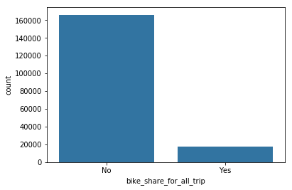

```python
# creating a uniform color for the plot
one_color = sb.color_palette()[0]
# creating plot for bike_share_for_all_trip
sb.countplot(data = Bike_clean, x='bike_share_for_all_trip', color=one_color);
```

### Question 2:

What is the age distribution of the riders?

### Visualization:

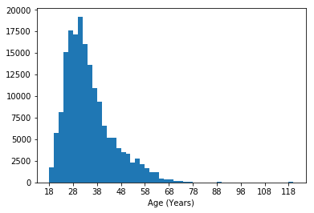

```python
# Create bins with step-size 2
bins = np.arange(18, Bike_clean['member_age'].max()+2,2)
# plotting of histogram for member age
plt.hist(data = Bike_clean, x = 'member_age', bins = bins);
# setting bin for x tick label
ticks = np.arange(18, Bike_clean['member_age'].max()+2,10)
plt.xticks(ticks);
plt.xlabel("Age (Years)");
```

### Observation:

It was observed that the histogram is right skewed and there is rider with age **118**, which happen to be an outlier.

### Question 3:

What is the user type distribution in data set?

### Visualization:

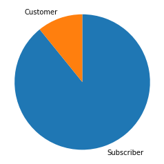

```python
# value count of user type
users_counts = Bike_clean['user_type'].value_counts()

# plotting pie chart for user type
plt.pie(users_counts, labels = users_counts.index, startangle = 90, counterclock = False)
plt.axis('square');
```

### Observation:

It was observed that **majority** of the riders are "Subscriber", while **minority** are are "Customer".

```python
# Dropping rows with undisclosed
valid_gender = Bike_clean.drop(Bike_clean[Bike_clean['member_gender'] == 'undisclosed'].index, inplace = False)
```

### Question 4:

What is the distribution of riders gender in the data set?

### Visualization:

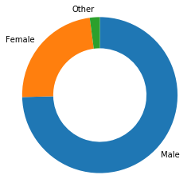

```python
# value count of members gender
gender_counts = valid_gender['member_gender'].value_counts()

# plotting of donut chart for gender distibution of memgers
plt.pie(gender_counts, labels = gender_counts.index, startangle = 90,
        counterclock = False, wedgeprops = {'width' : 0.4});
plt.axis('square');
```

### Observation:

**Majority** of the riders are male follow by female while the **least** is others.

### Question 5:

What is the **Age group** distribution in data set?

### Visualization:

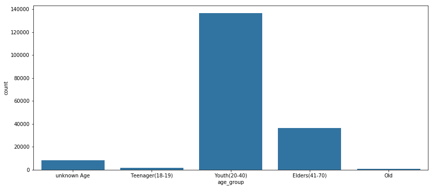

```python
# creating a uniform color for the plot
one_color = sb.color_palette()[0]
# Counting the frequency of each unique value in the 'generation_id' column, and sorting it in descending order

#set plot dimensions
plt.figure(figsize = [14,6])

# Plot the bar chart in the decreasing order of age group of memeber`
sb.countplot(data=Bike_clean, x='age_group', color=one_color);
```

### Discuss the distribution(s) of your variable(s) of interest. Were there any unusual points? Did you need to perform any transformations?

> A **bar chart** was plotted with **bike_share_for_all_trip** variables, those who use the bike share (**yes**)for all their trip are less than those who didn't use bike share(**No**) for all their trip.There was no unusual point, therefore there was no need to perform any transformation.

> An **histogram** was plot with the **Age** column,**majority** of rider falls between the age of **20-38** and there was an outlier of age **119**. TO this effect no transformation was performed.

> A **pie chart** was plotted with user_type variable and **Subscriber**users have the highest number of riders while **customer** users is less, no unusual point and no transformation was performed.

> A **donut chart** was plotted with member gender column, those who's gender was not recorded was dropped.

> A **bar chart** was plotted with age group column, the age group with the highest rider is the youth(20 - 40), no unusual point and there was no transformation performed.

### Of the features you investigated, were there any unusual distributions? Did you perform any operations on the data to tidy, adjust, or change the form of the data? If so, why did you do this?

> No unusual distribution

> Rows with undefined gender was dropped when plotting distribution of gender using donut plot,this was done because there was no definite category to put these set of people.

> In other to plot the age distribution an Age column was created by subtracting the year the data was collected from member birth year.

> A feature engineering was carried out on the age column to have age group column this is to enable me to plot the age group distribution of the data set.

## Bivariate Exploration

### Question 6:

What is the **Top 10 Start Stations** distribution in data set?

### Visualization:

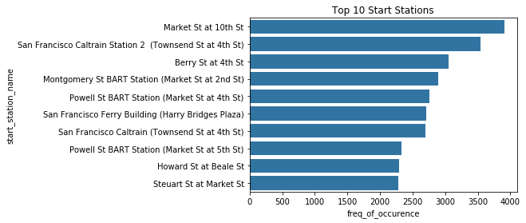

```python
start_station = Bike_clean.groupby("start_station_name").size().sort_values(ascending=False).head(10)
start_station = start_station.reset_index()
start_station.rename({0:"freq_of_occurence"},axis=1,inplace=True)
sb.barplot(y="start_station_name",x="freq_of_occurence",data=start_station,color=one_color);
plt.title("Top 10 Start Stations");
```

### Observation:

The station with the highest frequency of occurence is **Market St at 10th St** has the highest number of rider of about **4000** departing from the station while **Steuart St at Market St** is the least with about **2500** rider departing the station.

### Question 7:

What is the **Top 10 End Station** distribution in data set?

### Visualization:

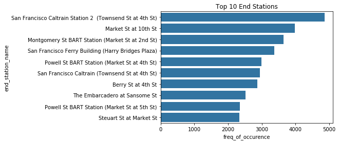

```python
end_station = Bike_clean.groupby("end_station_name").size().sort_values(ascending=False).head(10)
end_station = end_station.reset_index()
end_station.rename({0:"freq_of_occurence"},axis=1,inplace=True)
sb.barplot(y="end_station_name",x="freq_of_occurence",data=end_station,color=one_color);
plt.title("Top 10 End Stations");
```

### Question 8:

What is the relationship between **duration** and **distance** distribution in data set?

### Visualization:

```
Text(0,0.5,'Duration (hr)')
```

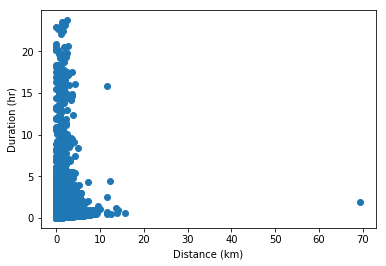

```python
# plotting scatter polt for duration and distance
plt.scatter(data = Bike_clean, x = 'distance',y = 'duration_hr');
plt.xlabel('Distance (km)')
plt.ylabel('Duration (hr)')
```

### Observation:

It was observed that the **highest** distance covered is **70 km** and it was coverd by a rider in less than 5 hours. This is an outlier.

```python
# this is to query the row with the maximum distance from the data set.
Bike_clean.query("distance == distance.max()")
```

|  | duration_hr | start_station_id | start_station_name | end_station_id | end_station_name | bike_id | user_type | member_age | member_gender | bike_share_for_all_trip | distance | age_group |
| --- | --- | --- | --- | --- | --- | --- | --- | --- | --- | --- | --- | --- |
| 112038 | 1.929167 | 21.0 | Montgomery St BART Station (Market St at 2nd St) | 300.0 | Palm St at Willow St | 4780 | Subscriber | 34 | Female | No | 69.469241 | Youth(20-40) |

```python
# drop the row with the maximum distance
Bike_clean.query('distance<60',inplace=True)
```

### Question 9:

What is the pattern of distribution between **distance** and **duration** when the outlier is neglected ?

### Visualization:

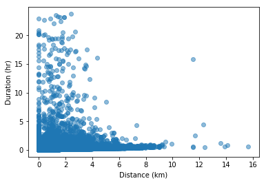

```python
sb.regplot(data = Bike_clean, x = 'distance', y = 'duration_hr',fit_reg = False,scatter_kws={'alpha':1/2});
plt.xlabel('Distance (km)')
plt.ylabel('Duration (hr)');
```

```python
# Drop rows with invalid age
valid_age = Bike_clean.drop(Bike_clean[Bike_clean['member_age'] <18].index, inplace = False)
```

### Question 10:

What is the relationship between duration and member age?

### Visualization:

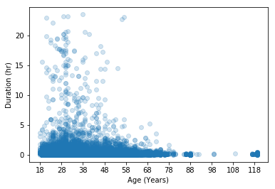

```python
# plotting scatter polt for duration and mumber_age
plt.scatter(data = valid_age , x = 'member_age', y ='duration_hr', alpha=1/5);
plt.xlabel('Age (Years)')
plt.ylabel('Duration (hr)');
ticks = np.arange(18, Bike_clean['member_age'].max()+2,10)
plt.xticks(ticks);
```

### Observation:

It was observed that majority of the riders falls between the age of **18 to 58 year** and the duration at which they ride for **about 2 hours**

### Question 11:

What is the relationship between distance and member age?

### Visualization:

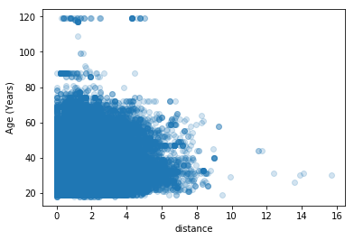

```python
# Drop rows with invalid age
valid_age = Bike_clean.drop(Bike_clean[Bike_clean['member_age'] <18].index, inplace = False)
# plotting a relationship between distance and member age
plt.scatter(data = valid_age , x = 'distance', y ='member_age', alpha=1/5);
plt.xlabel('distance')
plt.ylabel('Age (Years)');
ticks = np.arange(18, Bike_clean['member_age'].max()+2,10)
ticks = np.arange(0,Bike_clean['distance'].max()+0.5,2);
plt.xticks(ticks);
```

### Obsevation:

It was observed that majority of those cover the longest distance are between the age of 18 - 80 years of age.

### Question 12:

What is the relationship between **age group** and **user type**?

### Visualization:

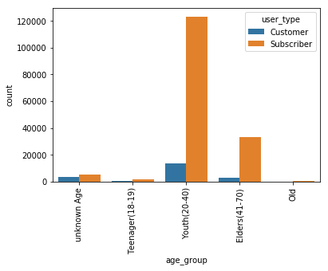

```python
sb.countplot(data=Bike_clean, x="age_group", hue="user_type");
plt.xticks(rotation=90);
```

### Observation:

The youth(20-40), has the highest level of both **subscriber** and **customer**

### Question 13:

What is relationship between **gender** with respect to the riders **age**?

### Visualization:

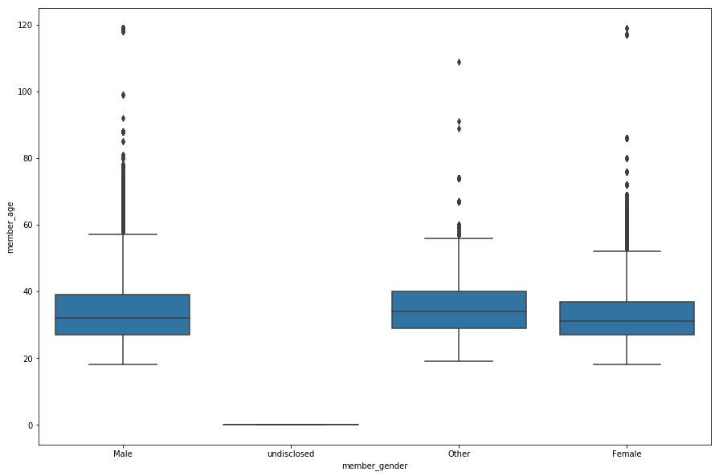

```python
# Box plot for relationship between
plt.figure(figsize=(15,10))
sb.boxplot(x='member_gender', y='member_age', data=Bike_clean, color=one_color);
```

### Observation:

All the rider's minimum age is close to 20 years while those who did'nt disclose their year of birth have zero.

### Question 14:

What is relationship between **gender** with respect to the riders **age** concidering those with valid age only?

### Visualization:

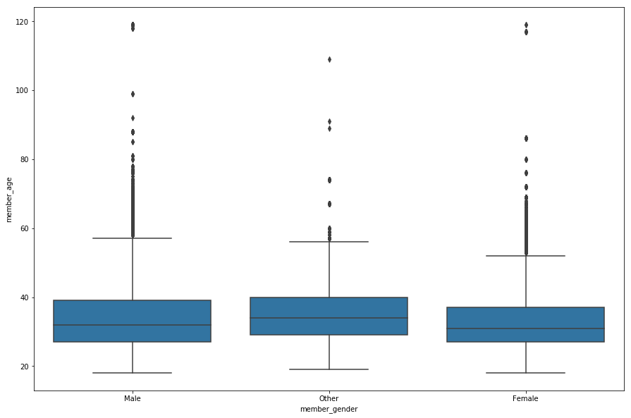

```python
# Drop rows with invalid age
valid_age = Bike_clean.drop(Bike_clean[Bike_clean['member_age'] <18].index, inplace = False)
# Box plot for relationship between
plt.figure(figsize=(15,10))
sb.boxplot(x='member_gender', y='member_age', data=valid_age, color=one_color);
```

### Observation:

The median of the **other** category is higher than that of the male and female category, while the median for the male is slightly higher than that of the female. Also, the normal distribution of all the given data is with a little skewness towards the right (positive skewness)

### Question 15:

What is the gender distribution of those who use bike share for all their trips?

### Visualization:

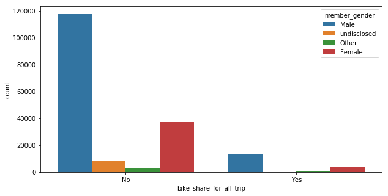

```python
# distance base on the use of bike for all trip
plt.figure(figsize=(10,5))
sb.countplot(data=Bike_clean, x="bike_share_for_all_trip", hue="member_gender");
```

### Observation:

Among those who did not use bike share for all their trips most of them are male then female while other is the least while those who used bike for all their trip is very minimal with male cartegory being the highest and those who did not disclose their gender didnt use it at all.

### Question 16:

What is the relationship between those who use the bike share for all their trip in relation to the distance covered by the riders?

### Visualization:

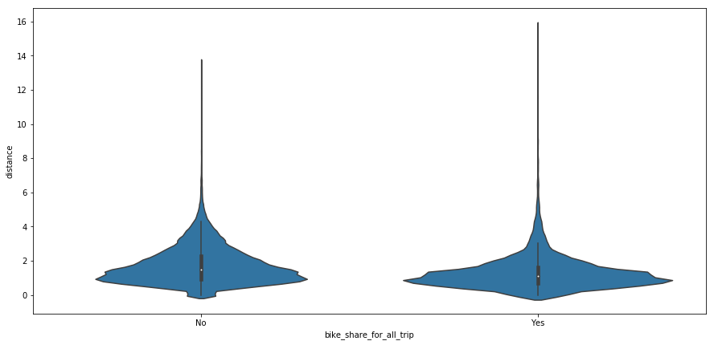

```python
plt.figure(figsize=(15,7))
sb.violinplot(x='bike_share_for_all_trip', y='distance', data=Bike_clean, color=one_color);
```

### Observation:

Majority of those who use bike share for all their trip cover a distance between 0 - 2 km and few people cover a didtance of 2 km and above, while among those who did not use the bike for all trip majority cover a distance of 0 - 4km and very few cover a distance of 4 km and above.

# Talk about some of the relationships you observed in this part of the investigation. How did the feature(s) of interest vary with other features in the dataset?

> Relationship between age group and user type, more of the youth (20-40) cartegory are most subscriber than customer this appears to be the same for all the age category.

### Did you observe any interesting relationships between the other features (not the main feature(s) of interest)?

> Yes

## Multivariate Exploration

### Question 16:

What is the relationship between duration_hr, Distance, and bike_share_for_all_trip?

### Visualization:

```
Text(0,0.5,'Distance (km)')
```

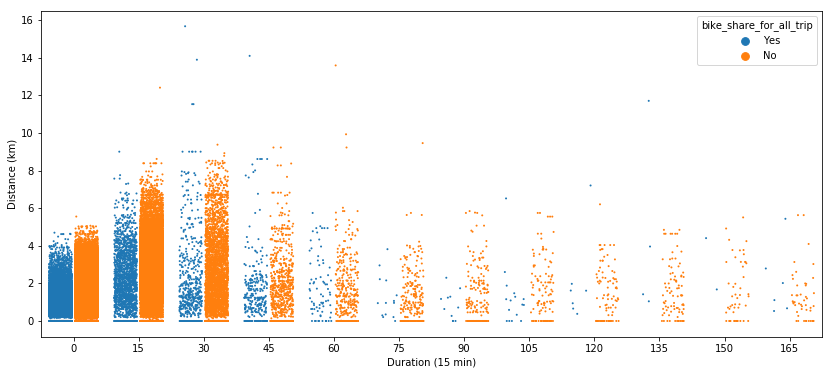

```python
# creating an hourly integer variable
Bike_clean['duration_15mins'] = (((Bike_clean['duration_hr']*60)//15)*15).astype(int)
# setting plot dimensions
plt.figure(figsize=[14,6])

# plotting Multivarite using (duration_hr, Distance and bike_share_for_all_trip)

sb.stripplot(data = Bike_clean.query('duration_hr<=3'), x = 'duration_15mins', y = 'distance', hue = 'bike_share_for_all_trip',
             hue_order = ['Yes','No'], size = 2,jitter=0.35,dodge=True)
plt.xlabel('Duration (15 min)')
plt.ylabel('Distance (km)')
```

### Observation:

It was observed that as more riders did not uses bike share for all their trip for distance between 0 to 10 km which requries shorter duration of less than an hour.

### Question 17:

What is the relationship between member_age, distance, and duration?

### Visualization:

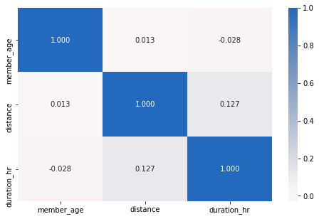

```python
# plotting of hat map for three numeric variable (member_age, distance, duration_hr)
numeric_vars = ['member_age', 'distance', 'duration_hr']
# correlation plot
plt.figure(figsize = [8, 5])
sb.heatmap(Bike_clean[numeric_vars].corr(), annot = True, fmt = '.3f',
           cmap = 'vlag_r', center = 0);
```

### Observation:

There is a weak negative correlation between member age and duration, while there is week positve correlation between distance and member age, lastly there is a weak positive correlation between distance and duration.

### Question 18:

What is the relationship between member_gender, distance, and duration?

### Visualization:

```
Text(0,0.5,'Distance (km)')
```

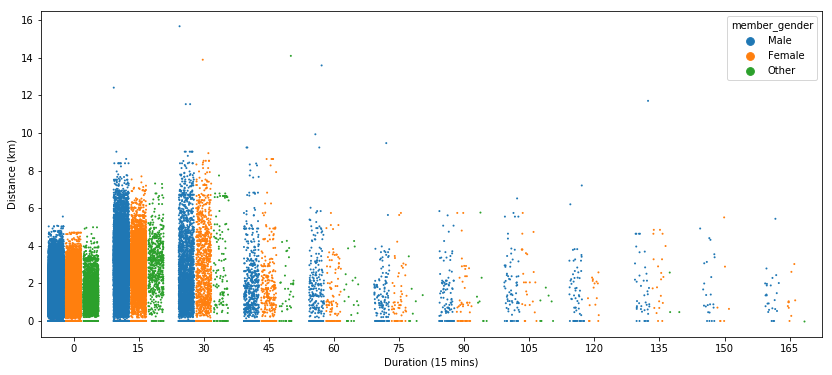

```python
# Dropping unknown gender
valid_gender = Bike_clean.drop(Bike_clean[Bike_clean['member_gender'] == 'undisclosed'].index, inplace = False)

plt.figure(figsize=[14,6])

# plotting Multivarite using (duration_hr, Distance and bike_share_for_all_trip)

sb.stripplot(data = valid_gender.query('duration_hr<=3'), x = 'duration_15mins', y = 'distance', hue = 'member_gender',
             hue_order = ['Male','Female','Other'], size = 2,jitter=0.35,dodge=True)
plt.xlabel('Duration (15 mins)')
plt.ylabel('Distance (km)')
```

### Observation:

Majority of those who ride for the duration of 60 minutes and cover a distance between 0 and 10 km are those in the **Male** category, follow by the **female** and then those in the **Other** category.

### Question 19:

What is the relationship between member_gender, member_age, and user type?

### Visualization:

[figure not shown]

```python
# Plotting multivari plot using (user_type, age and )
g = sb.FacetGrid(data = Bike_clean, col = 'user_type', size = 5)
g.map(sb.violinplot, 'member_gender', 'member_age')
```

### Talk about some of the relationships you observed in this part of the investigation. Were there features that strengthened each other in terms of looking at your feature(s) of interest?

> Relationship between member_gender, distance, and duration. This helps to see the gender distribution of the riders helps to see the gender of rider that covers a particular distance at a perticular time.

> Relationship between member_gender, member_age, and user type. The Age variables help to reveal an idea of the magnitude of riders that fall in a perticular age when concidering the user type and their gender.

> Relationship between member_age, distance, and duration. Age variable reveals the correlation between the distance and duration the riders covered.

### Were there any interesting or surprising interactions between features?

> Yes

## Conclusions

> Having carried out an exploratory anaysis of the Ford GoBike data set, which includes information about individuals who made rides in a bike-sharing system covering the greater San Francisco Bay area in February 2019. It was observed that majority of the riders are men from the 18-40years followed 41-60years and most of them were subscribers.

## Limitation

> The birth year column with missing data were filled with 2019 which is the year the data was collected.

> The member gender column was with missing value was replaced with "undisclosed" this is because the affected roles contain some useful data for the analysis.

> The missing values in the start station name and end station were not dropped but was left just to retain some vital data.

> During visualization some rows were drop along the line to have a good plotting scale.